# Sole 8ab: InterCatch to CEF Format and Discards Raising

JB Lecomte

2026-10-05

## Overview

This vignette demonstrates the workflow for processing sole (*Solea solea*) stock data in ICES Division 8ab. The workflow covers two main steps:

1. **Converting InterCatch data to the CEF (Catch Estimation Framework) format**
2. **Raising discards** across hierarchical strata when discard observations are missing

## Required Packages

```r
library("icesVocab")
library("icesSD")
library("tidyverse")
library("here")
library("glue")
library("data.table")
```

The workflow also relies on several custom functions sourced locally (see sections below).

## Part 1: From InterCatch to CEF Format

### Source Helper Functions

```r
source(here("R/funIntercatchCEF.R"))
source(here("R/funICoutCEF.R"))
source(here("R/funMakeRelation.R"))
source(here("R/utils.R"))
```

### Convert InterCatch Output to CEF List

The function `funICoutCEF()` reads InterCatch export files and converts them into a named list following the CEF data structure. The result is stored in `list_cef`.

```r
path_to_data <- here("WGRDBESstockCoord/personal/JB/data")

list_cef <- funICoutCEF(
  dat_path       = glue("{path_to_data}/"),
  years          = 2024,
  metier6        = "Fleet",
  output_format  = "to_list",
  out_path       = path_to_data,
  keep_temp_file = TRUE,
  file_prefix    = "sol_8ab"
)
```

[output not shown]

### Verify Total Landings

As a quality control step, compute the total landings (in tonnes) from the CEF object. This value will be used later to verify that the discards raising procedure conserves the total landings mass.

```r
list_cef_total_landings <- list_cef$catches %>%
  filter(
    catchCategory == "Lan",
    originType   == "WGEstimate",
  ) %>%
  mutate(total = as.numeric(total)) %>%
  summarise(
    total     = sum(total),
    total_ton = total / 1000
  )

list_cef_total_landings
```

```
#>     total total_ton
#> 1 2595054  2595.054
```

## Part 2: Discards Raising

When discard observations are absent for certain strata, discards must be **raised** (i.e., estimated) from strata where both landings and discards are observed. The procedure applies a hierarchical sequence of strata, from finest to coarsest, until all landing records without discards have been assigned a raised discard estimate.

### Strata Notation

| Code | Dimension |
| --- | --- |
| `c` | Country |
| `q` | Quarter |
| `f` | Fleet (métier 6) |
| `a` | Area (ICES div.) |
| `g` | Gear |
| `sg` | Super-gear (O, G, T, …) |

### Source Helper Functions

```r
source(here("R/cef_add_strata.R"))
source(here("R/split_L_with_without_D.R"))
source(here("R/raise_discards_strata.R"))
source(here("R/strata_coverage_summary.R"))
```

### Split Records: With vs. Without Discards

`split_L_with_without_D()` partitions the catches into:

- `dfw_stock_overview_L_D` — domain rows with **both** landings and discards
- `dfw_stock_overview_L_noD` — domain rows with **landings only** (no discard obs.)

```r
list_stock_overview <- split_L_with_without_D(
  cef_catches = list_cef$catches,
  originType  = "WGEstimate",
  domain      = "domainCatchDis",
  add_strata  = TRUE
)

# Sanity check: total landings must be preserved after splitting
sum(list_stock_overview$dfw_stock_overview$Lan)
```

```
#> [1] 2595054
```

```r
sum(list_stock_overview$dfw_stock_overview_L_D$Lan) +
  sum(list_stock_overview$dfw_stock_overview_L_noD$Lan)
```

```
#> [1] 2595054
```

### Explore Coverage by Stratum

Before raising, assess discard coverage at each stratum level using `strata_coverage_summary()`. This helps choose the appropriate raising hierarchy.

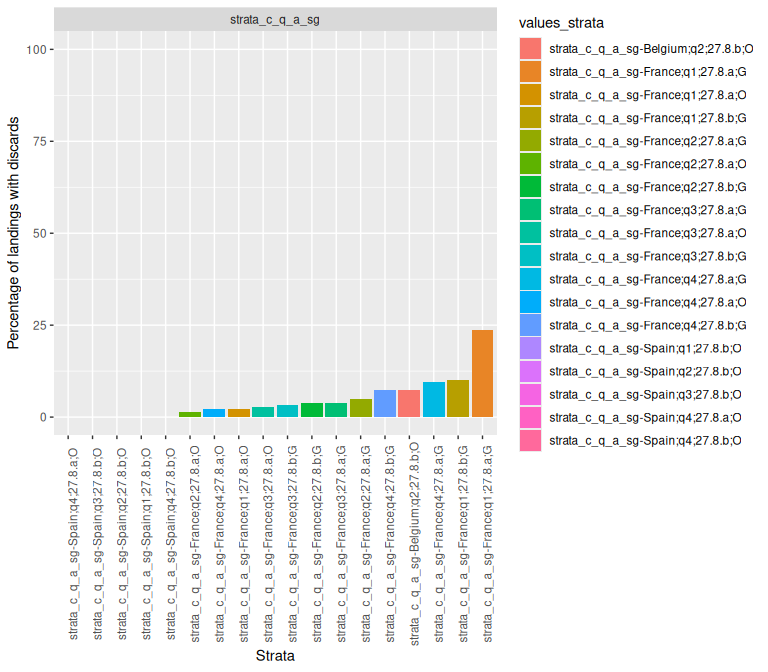

```r
strata_raising_ordered_full <- c(
  "strata_c_q_f",
  "strata_c_q_a_g",
  "strata_c_q_a_sg",
  "strata_q_a_sg",
  "strata_q_a",
  "strata_q"
)

results_coverage <- map(strata_raising_ordered_full, function(strata_var) {
  strata_coverage_summary(
    dfw_stock_overview      = list_stock_overview$dfw_stock_overview,
    dfw_stock_overview_L_D  = list_stock_overview$dfw_stock_overview_L_D,
    dfw_stock_overview_L_noD = list_stock_overview$dfw_stock_overview_L_noD,
    strata_var              = !!sym(strata_var)
  )
}) %>%
  set_names(strata_raising_ordered_full)


print(results_coverage$strata_c_q_a_sg$plot_strata_coverage)
```

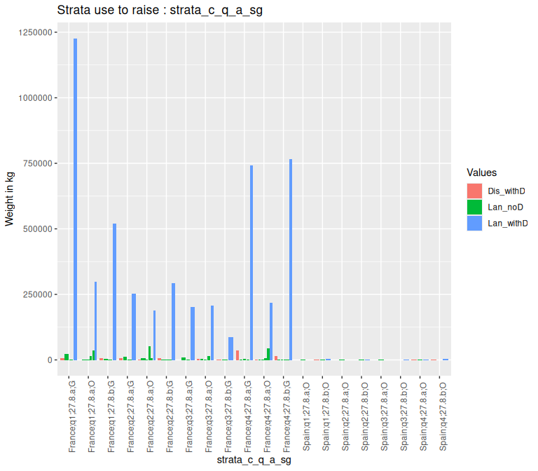

```r
print(results_coverage$strata_c_q_a_sg$plot_landings_discards_coverage)
```

### Define the Raising Hierarchy

Based on the coverage results, define the ordered sequence of strata for raising. Finer strata are attempted first; coarser strata are used as fallback.

```r
strata_raising_ordered <- c(
  "strata_c_q_f",
  # "strata_c_q_a_g",  # commented out if coverage is insufficient
  "strata_c_q_a_sg",
  "strata_q_a_sg",
  "strata_q_a",
  "strata_q"
)

### only keep strata to be used in discards raising
list_stock_overview <- purrr::map(list_stock_overview,
                           cef_remove_strata,
                           extra_strata = strata_raising_ordered)
```

### Raise Discards Iteratively

The loop iterates over the strata hierarchy. At each step, `raise_discards_strata()` assigns raised discards to the remaining unmatched landing-only rows. Records that have been raised are moved out of `dfw_stock_overview_L_noD` at each iteration.

```r
list_raised_discards <- NULL
### unpack list : load data frames within the lsit in the R environment
unpack_list(list_stock_overview)

for (i_strata in strata_raising_ordered) {
  message("Raising at stratum: ", i_strata)

  list_raised_discards[[i_strata]] <- raise_discards_strata(
    strata_var               = i_strata,
    dfw_stock_overview_L_D   = dfw_stock_overview_L_D,
    dfw_stock_overview_L_noD = dfw_stock_overview_L_noD
  )

  # Update L_noD: remove rows that were successfully raised in this step
  dfw_stock_overview_L_noD <- list_raised_discards[[i_strata]]$dfw_stock_overview_L_noD
}
```

```
#> Raising at stratum: strata_c_q_f
#> Raising at stratum: strata_c_q_a_sg
#> Raising at stratum: strata_q_a_sg
#> Raising at stratum: strata_q_a
#> Raising at stratum: strata_q
#> Warning in raise_discards_strata(strata_var = i_strata, dfw_stock_overview_L_D
#> = dfw_stock_overview_L_D, : No discards left to be raised with strata_q
```

```r
# Combine all raised discard rows across strata
df_raised_all <- list_raised_discards %>%
  keep(~ "df_raised_discards" %in% names(.x)) %>%
  map("df_raised_discards") %>%
  bind_rows(.id = "strata")

# Final table: observed L+D rows + all raised rows
dfw_stock_overview_L_D_raised <- bind_rows(dfw_stock_overview_L_D, df_raised_all)

# domainBiology lookup (dropped from the wide table by split_L_with_without_D())
cef_catches_domainBiology <- list_stock_overview$cef_catches_originType %>%
  select(strata_full, domainBiology, catchCategory) %>%
  filter(!is.na(domainBiology))

# pivot table in long format and re-attach domainBiology
df_stock_overview_L_D_raised <- pivot_longer(dfw_stock_overview_L_D_raised,
                                             cols = any_of(c("Lan", "Dis", "BMS")),
                                             names_to = "catchCategory",
                                             values_to = "Catchkg") %>%
  left_join(cef_catches_domainBiology,
            by = join_by(strata_full, catchCategory))
```

### Quality Checks

Verify that the raising procedure is internally consistent:

```r
# 1. Row count: raised rows == original L_noD rows
stopifnot(
  dim(list_stock_overview$dfw_stock_overview_L_noD)[1] == dim(df_raised_all)[1]
)

# 2. Landings mass: raised rows conserve the original L_noD landings
stopifnot(
  abs(sum(df_raised_all$Lan) -
      sum(list_stock_overview$dfw_stock_overview_L_noD$Lan)) < 1e-6
)

# 3. Grand total landings: matches original CEF total
stopifnot(
  abs(list_cef_total_landings$total -
      (sum(dfw_stock_overview_L_D$Lan) + sum(df_raised_all$Lan))) < 1e-6
)
```

## Part 3: Summarise and Visualise Raising Results

### Compute Raising Percentages

Build a summary table showing what percentage of total landings were raised at each stratum level.

```r
df_strata_summary_raising <- list_raised_discards %>%
  keep(~ "strata_summary_raising" %in% names(.x)) %>%
  map("strata_summary_raising") %>%
  bind_rows(.id = "strata") %>%
  mutate(
    percentage_landings_raised_with_noDiscards =
      round(persentage_landings_raised_without_D, digits = 4) * 100,
    percentage_landings_raised =
      round(raised_landings / total_landings, digits = 4) * 100
  )

df_strata_summary_raising
```

```
#> # A tibble: 5 × 9
#>   strata          total_landings_with_no…¹ landings_with_Discards total_landings
#>   <chr>                              <dbl>                  <dbl>          <dbl>
#> 1 strata_c_q_f                     445033.               2150021.       2595054.
#> 2 strata_c_q_a_sg                  325473.               2150021.       2475494.
#> 3 strata_q_a_sg                     74635.               2150021.       2224656.
#> 4 strata_q_a                        29493.               2150021.       2179514.
#> 5 strata_q                              0                2150021.       2150021.
#> # ℹ abbreviated name: ¹total_landings_with_noDiscards
#> # ℹ 5 more variables: raised_landings <dbl>,
#> #   persentage_landings_raised_without_D <dbl>, discards_ratio_raised <dbl>,
#> #   percentage_landings_raised_with_noDiscards <dbl>,
#> #   percentage_landings_raised <dbl>
```

### Plot 1 — % of L-only Landings Raised per Stratum

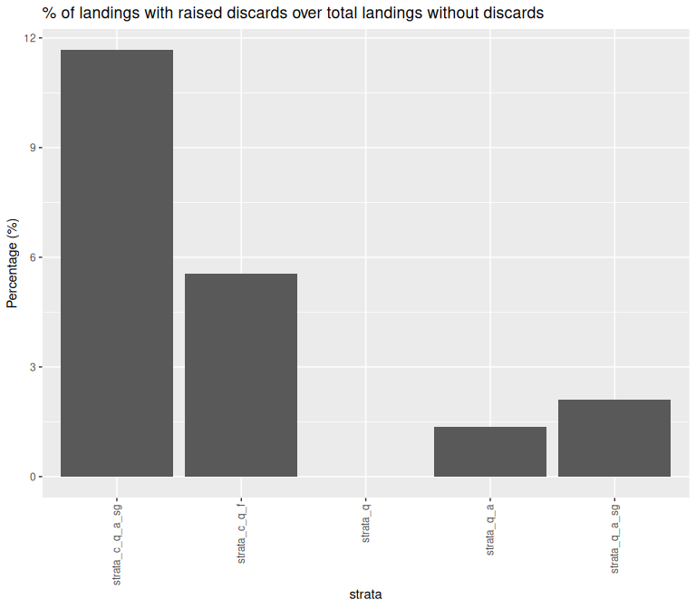

```r
plot_stratum_raised_percentage <- ggplot() +
  geom_col(
    data = df_strata_summary_raising,
    aes(x = strata, y = percentage_landings_raised_with_noDiscards),
    position = position_dodge2()
  ) +
  theme(axis.text.x = element_text(angle = 90, hjust = 1, vjust = 0.4)) +
  ylab("Percentage (%)") +
  ggtitle("% of landings with raised discards over total landings without discards")

plot_stratum_raised_percentage
```

### Plot 2 — % of Total Landings Raised per Stratum

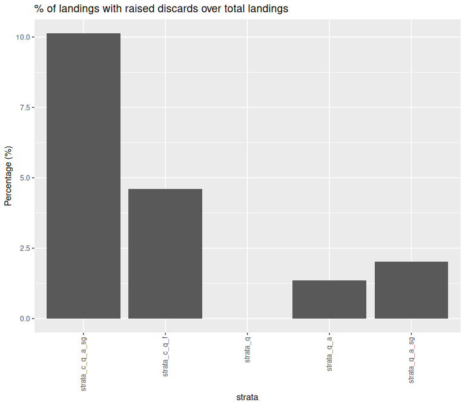

```r
plot_stratum_raised_percentage_total <- ggplot() +
  geom_col(
    data = df_strata_summary_raising,
    aes(x = strata, y = percentage_landings_raised),
    position = position_dodge2()
  ) +
  theme(axis.text.x = element_text(angle = 90, hjust = 1, vjust = 0.4)) +
  ylab("Percentage (%)") +
  ggtitle("% of landings with raised discards over total landings")

plot_stratum_raised_percentage_total
```

```r
list_plot_stratum_raised <- list(
  plot_stratum_raised_percentage       = plot_stratum_raised_percentage,
  plot_stratum_raised_percentage_total = plot_stratum_raised_percentage_total
)
```

# Comparison with IC raising

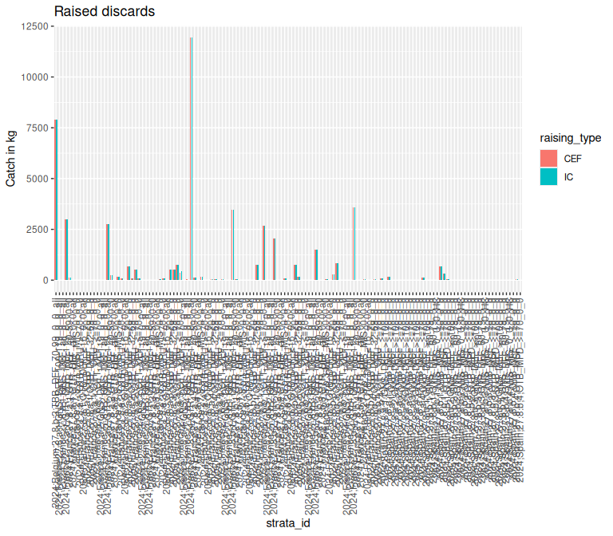

```r
source(here("WGRDBESstockCoord/personal/JB/load_IC_raised_allocated_2024.R"))

df_stock_overview_L_D_raised <- df_stock_overview_L_D_raised %>%
  mutate(raising_type = "CEF")

df_stock_overview_L_D_comparison <- bind_rows(df_stock_overview_L_D_raised,
                                              df_stock_overview_raised_w_2024_IC)


df_stock_overview_L_D_comparison_Dis <- df_stock_overview_L_D_comparison %>%
  filter(catchCategory == "Dis") %>%
  mutate(strata_id = glue("{year};{vesselFlagCountry};{areaValue};{seasonValue};{fleetValue}")) %>%
  droplevels()


plot_comparison <- ggplot() +
  geom_col(data = df_stock_overview_L_D_comparison_Dis,
           aes(x = strata_id, y =  Catchkg, fill = raising_type),
           position = position_dodge2()) +
  theme(axis.text.x = element_text(angle = 90, hjust = 1, vjust = 0.4)) +
  ylab("Catch in kg") +
  ggtitle("Raised discards")

plot_comparison
```

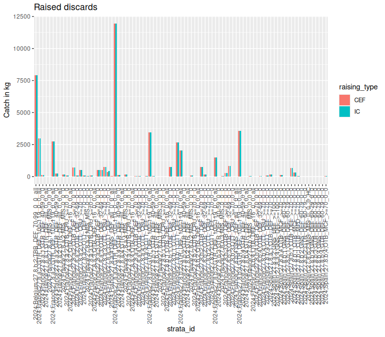

```r
df_stock_overview_L_D_comparison_Dis0 <- df_stock_overview_L_D_comparison_Dis %>%
  filter(Catchkg > 0) %>%
  droplevels()


plot_comparison_Dis0 <- ggplot() +
  geom_col(data = df_stock_overview_L_D_comparison_Dis0,
           aes(x = strata_id, y =  Catchkg, fill = raising_type),
           position = position_dodge2()) +
  theme(axis.text.x = element_text(angle = 90, hjust = 1, vjust = 0.4)) +
  ylab("Catch in kg") +
  ggtitle("Raised discards")

plot_comparison_Dis0
```

# Further work

1. Add threshold to avoid using landings associated with poorly represented discards.